# Temperatura JP x CG

```r
climas = read_csv(here::here("data/clima_cg_jp-semanal.csv"),
                  col_types = "cTdddddd")

glimpse(climas)
```

```
## Observations: 2,748
## Variables: 8
## $ cidade <chr> "Campina Grande", "Campina Grande", "Campina Grande", "...
## $ semana <dttm> 1992-12-27, 1993-01-03, 1993-01-10, 1993-01-31, 1993-0...
## $ tmedia <dbl> 26.13333, 26.11905, 25.76667, 25.74000, 26.31429, 26.28...
## $ tmax   <dbl> 30.4, 32.4, 32.2, 32.0, 32.7, 32.7, 32.3, 32.3, 32.1, 3...
## $ tmin   <dbl> 20.7, 19.3, 19.7, 19.9, 19.6, 20.0, 20.4, 21.2, 19.0, 1...
## $ chuva  <dbl> 0.0, 0.0, 0.0, 0.4, 0.3, 0.0, 4.9, 0.0, 0.0, 6.1, 0.4, ...
## $ mes    <dbl> 12, 1, 1, 1, 2, 2, 2, 2, 10, 11, 11, 11, 11, 12, 12, 12...
## $ ano    <dbl> 1992, 1993, 1993, 1993, 1993, 1993, 1993, 1993, 1993, 1...
```

## Temperatura

### Onde é mais quente?

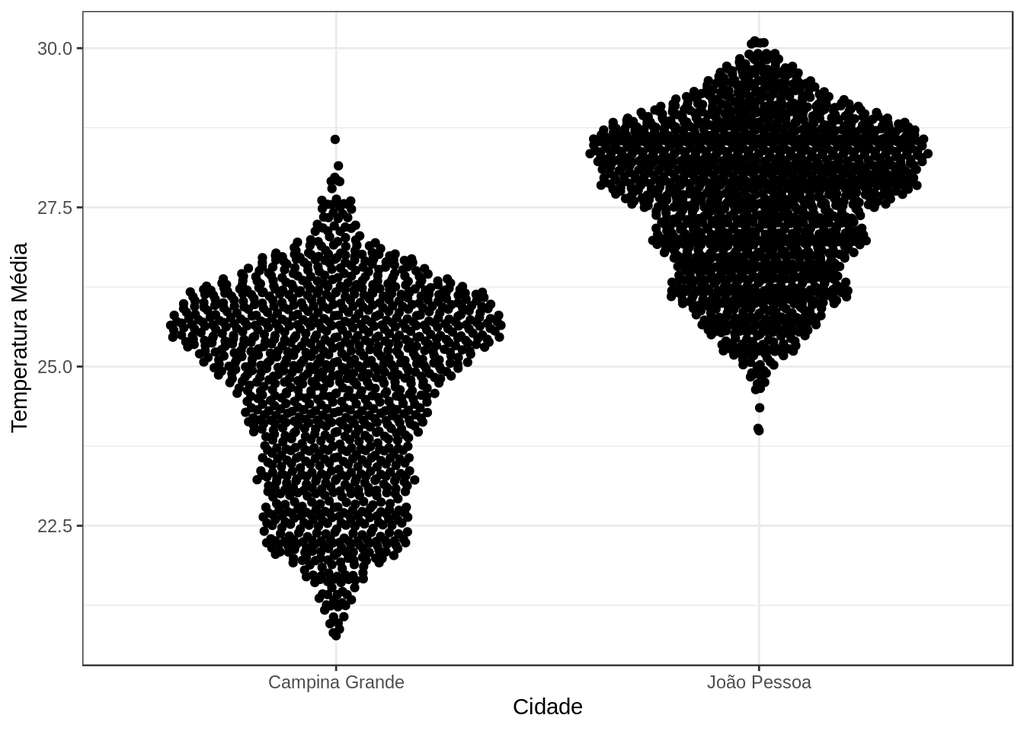

```r
climas %>%
    ggplot(mapping = aes(x = cidade, y = tmedia)) +
    xlab("Cidade") + ylab("Temperatura Média") +
    geom_quasirandom()
```

### As temperaturas máximas semanais (o pico do calor) são tão diferentes quanto as médias? Mais?

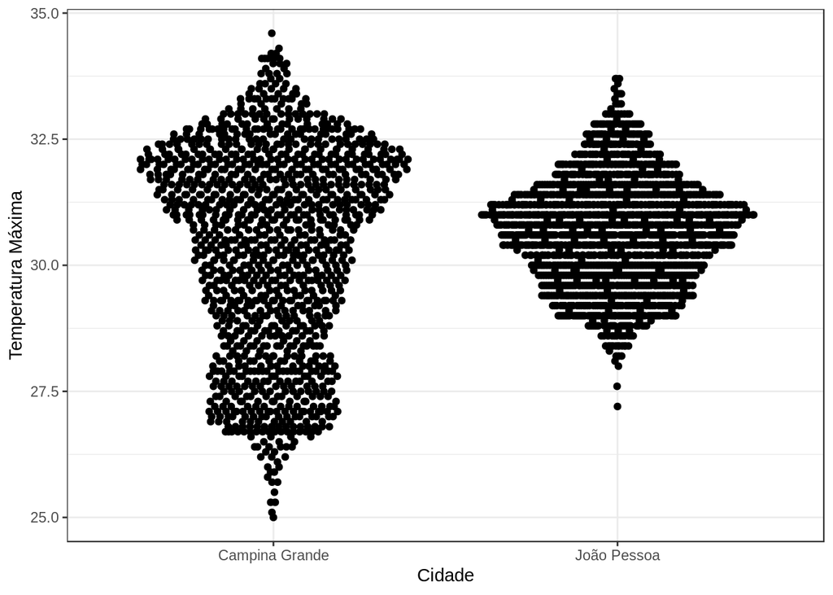

```r
climas %>%
    ggplot(mapping = aes(x = cidade, y = tmax)) +
    xlab("Cidade") + ylab("Temperatura Máxima") +
    geom_quasirandom()
```

Mesmo que a temperatura média de Campina Grande seja menor que a temperatura média de João Pessoa, maiores temperaturas são mais frequentes em Campina Grande que em João Pessoa, como podemos ver no gráfico acima. Entretanto, a média das temperaturas máximas de João Pessoa gira é mais constante que a de Campina Grande: enquanto João Pessoa tem a temperatura máxima mais frequente em torno dos 31 graus, Campina Grande tende a ter frequência maior tanto nas temperaturas máximas mais altas quanto nas temperaturas máximas mais baixas.

### Quais os meses mais quentes e mais frios?

Para responder essa pergunta, agrupamos os dados por mês, para em seguida visualizar a informação:

```r
clima_por_mes <- climas %>%
    group_by(mes) %>%
    summarise(mean_temp = mean(tmedia, na.rm = TRUE))

glimpse(clima_por_mes)
```

```
## Observations: 12
## Variables: 2
## $ mes       <dbl> 1, 2, 3, 4, 5, 6, 7, 8, 9, 10, 11, 12
## $ mean_temp <dbl> 27.28775, 27.44452, 27.47566, 26.91009, 26.16805, 24...
```

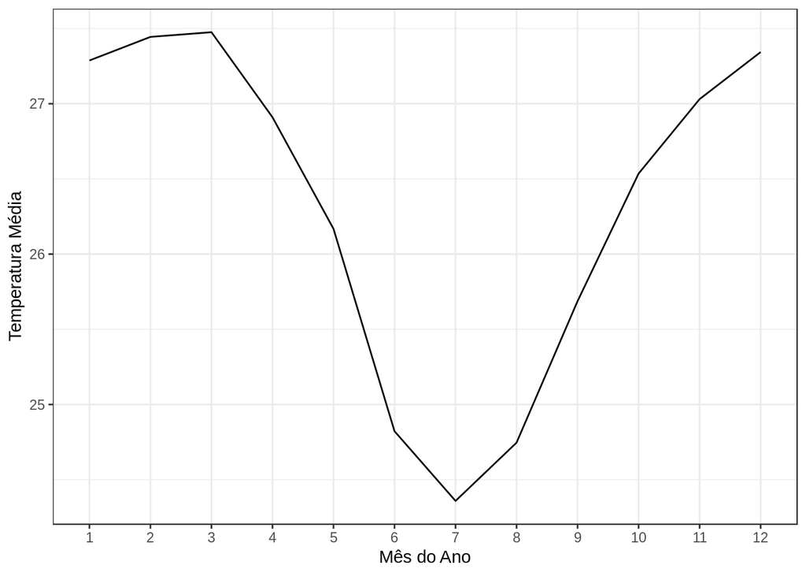

```r
clima_por_mes %>%
    ggplot(mapping = aes(x = factor(mes), y = mean_temp)) +
    xlab("Mês do Ano") + ylab("Temperatura Média") +
    geom_line(group = 1)
```

É possível notar que a temperatura média é menor nos meses do meio do ano.

### Qual foi o São João mais frio de CG que está nos nossos dados?

```r
climas_cg <- climas %>%
    filter(cidade == "Campina Grande") %>%
    filter(mes == 6)
glimpse(climas_cg)
```

```
## Observations: 95
## Variables: 8
## $ cidade <chr> "Campina Grande", "Campina Grande", "Campina Grande", "...
## $ semana <dttm> 1995-06-04, 1995-06-11, 1995-06-18, 1995-06-25, 1996-0...
## $ tmedia <dbl> 22.40000, 22.20952, 23.29524, 21.89048, 22.40476, 22.23...
## $ tmax   <dbl> 26.7, 27.1, 28.6, 27.5, 27.3, 26.7, 27.6, 27.1, 27.2, 2...
## $ tmin   <dbl> 18.5, 18.3, 17.1, 18.2, 18.3, 18.6, 18.0, 17.2, 16.7, 1...
## $ chuva  <dbl> 41.1, 36.3, 19.1, 67.7, 37.7, 21.0, 8.6, 10.2, 6.8, 0.6...
## $ mes    <dbl> 6, 6, 6, 6, 6, 6, 6, 6, 6, 6, 6, 6, 6, 6, 6, 6, 6, 6, 6...
## $ ano    <dbl> 1995, 1995, 1995, 1995, 1996, 1996, 1996, 1996, 1996, 1...
```

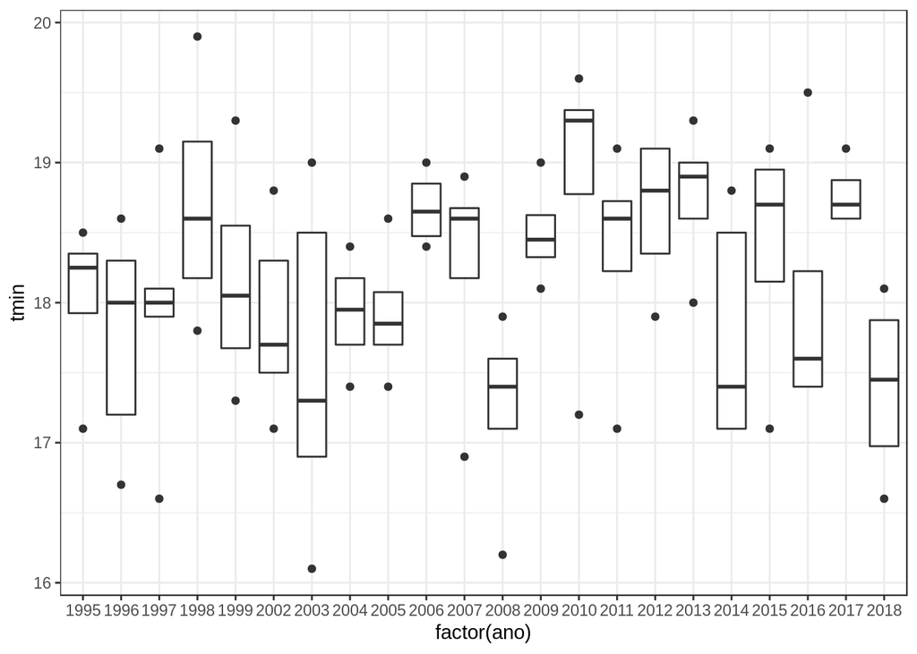

```r
climas_cg %>%
    group_by(ano) %>%
    ggplot(mapping = aes(x=factor(ano), y = tmin)) +
    geom_boxplot(coef = 0)
```

## Chuva

Como é a distribuição do volume de chuvas por semana em JP e CG? A chuva varia mais ou menos que a temperatura? O formato da distribuição é igual?